# Collecting NEON Driver Data

John W Smith Jr

1/25/2022

# Collecting TALL Driver Data

If we want to run DALECev at Talladega National Forest (TALL) we need to collect a handful of daily driver information to get the process model off the ground. This information includes:

- Daily temperature data (minimum, maximum)
- Daily shortwave radiation data
- Atmospheric Carbon
- Latitude
- Leaf Mass per Area

In this document we are going to focus on: daily temperature data, daily shortwave radiation data.

We are going to pull NEON data using the `neonstore` package, available on GitHub.

## Temperature Data

```r
## load neonstore package
library(neonstore)

## download temperature data for TALL
## the temperature data we are downloading is
## triple aspirated air temperature
neon_download(product = 'DP1.00003.001', site = 'TALL')
```

```
##   comparing hashes against local file index...
```

```
##   omitting 338 files previously downloaded
```

```r
## show the data products we have stored
print(unique(neon_index()$table))
```

```
##  [1] "TAAT_1min-basic"                "TAAT_30min-basic"
##  [3] "EML"                            "readme"
##  [5] "sensor_positions"               "variables"
##  [7] "SRPP_1min-basic"                "SRPP_30min-basic"
##  [9] "nsae-basic"                     "categoricalCodes"
## [11] "validation"                     "ltr_chemistrySubsampling-basic"
## [13] "ltr_fielddata-basic"            "ltr_litterCarbonNitrogen-basic"
## [15] "ltr_litterLignin-basic"         "ltr_massdata-basic"
## [17] "ltr_pertrap-basic"              "bbc_chemistryPooling-basic"
## [19] "bbc_dilution-basic"             "bbc_percore-basic"
## [21] "bbc_rootChemistry-basic"        "bbc_rootmass-basic"
## [23] "vst_apparentindividual-basic"   "vst_mappingandtagging-basic"
## [25] "vst_perplotperyear-basic"       "vst_shrubgroup-basic"
```

```r
## read the 30 minute measurements into temp_table
temp_table <- neon_read("TAAT_30min-basic", site = 'TALL')
## format the end dates so that we can sort them
temp_table$Date <- format(temp_table$endDateTime, format = '%Y-%m-%d')

## sort the dates so we know how many unique days there are measurements for
sorted.Date.unique <- sort(unique(temp_table$Date))

## create the temp_info_TALL dataframe so that we can store
## Date, Minimum Temp, Maximum Temp
temp_info_TALL <- matrix(NA, nrow = length(sorted.Date.unique), ncol = 3)
colnames(temp_info_TALL) <- c('Date', 'MinT', 'MaxT')
temp_info_TALL <- as.data.frame(temp_info_TALL)

## for loop to extract minimum and maximum temps
for (i in 1:length(sorted.Date.unique)){
  temp_info_TALL$Date[i] <- sorted.Date.unique[i]
  temp_info_TALL$MinT[i] <- min(temp_table$tempTripleMinimum[which(temp_table$Date == sorted.Date.unique[i])])
  temp_info_TALL$MaxT[i] <- max(temp_table$tempTripleMaximum[which(temp_table$Date == sorted.Date.unique[i])])
}
## I went ahead and remove this data point, which tells me that it
## was -70 degrees C in Florida
#temp_info_TALL$MinT[2502] <- NA
```

Now that we’ve extracted the min and max temps, let’s do a quick sanity check by plotting them.

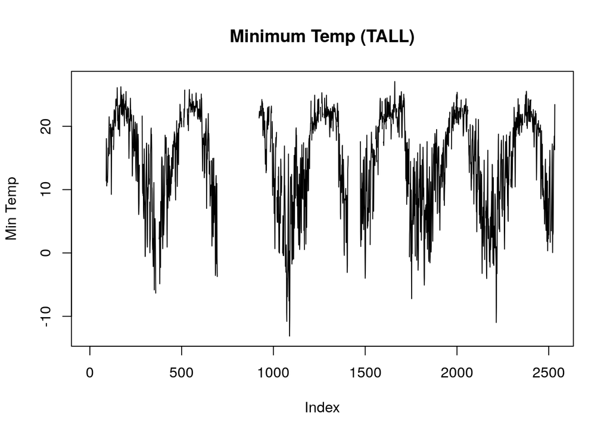

```r
plot(temp_info_TALL$MinT, type = 'l', main = 'Minimum Temp (TALL)', ylab = 'Min Temp')
```

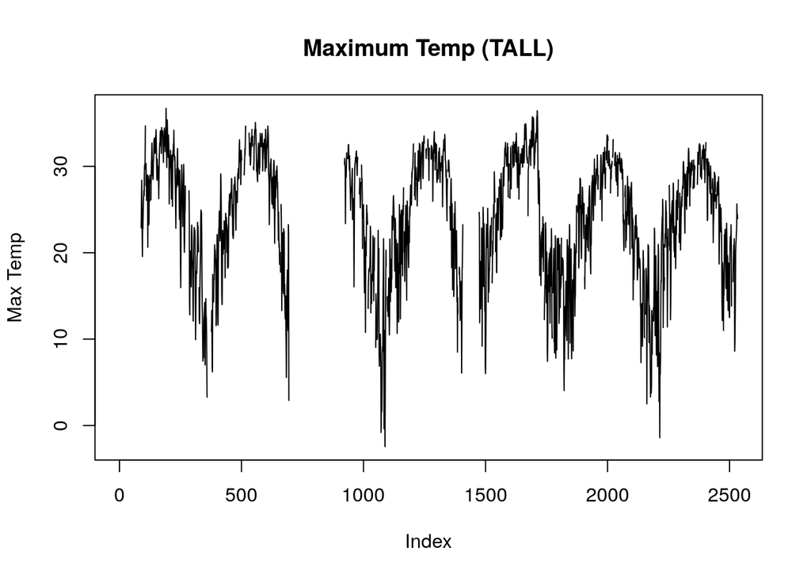

```r
plot(temp_info_TALL$MaxT, type = 'l', main = 'Maximum Temp (TALL)', ylab = 'Max Temp')
```

We see that we have some gaps missing from the data, and we’ll have to do an imputation. We’ll try this two different ways - once with `na_interpolation` in the `imputeTS` package, and once with a Heteroskedastic Gaussian Process from the `hetGP` package.

```r
## load imputeTS
library(imputeTS)
## Interpolate and store
temp_info_TALL$MaxTInterp <- na_interpolation(temp_info_TALL$MaxT)
temp_info_TALL$MinTInterp <- na_interpolation(temp_info_TALL$MinT)

## load hetGP
library(hetGP)

## fit heteroskedastic GP for imputation of the min temp
mint_impute <- mleHetGP(
        X = matrix(which(!is.na(temp_info_TALL$MinT))/length(temp_info_TALL$MinT), ncol = 1),
        Z = temp_info_TALL$MinT[which(!is.na(temp_info_TALL$MinT))])
## extract predictions at missing locations
GP_preds_mint <- predict(object = mint_impute,
                    x = matrix(which(is.na(temp_info_TALL$MinT))/length(temp_info_TALL$MinT), ncol = 1))
## store predictions in TALL temp info df
temp_info_TALL$MinTGP <- temp_info_TALL$MinT
temp_info_TALL$MinTGP[which(is.na(temp_info_TALL$MinTGP))] = GP_preds_mint$mean

## fit heteroskedastic GP for imputation of the max temp
maxt_impute <- mleHetGP(
  X = matrix(which(!is.na(temp_info_TALL$MaxT))/length(temp_info_TALL$MaxT), ncol = 1),
  Z = temp_info_TALL$MaxT[which(!is.na(temp_info_TALL$MaxT))])
## extract predictions at missing locations
GP_preds_maxt <- predict(object = maxt_impute,
                         x = matrix(which(is.na(temp_info_TALL$MaxT))/length(temp_info_TALL$MaxT), ncol = 1))
## store predictions in TALL temp info df
temp_info_TALL$MaxTGP <- temp_info_TALL$MaxT
temp_info_TALL$MaxTGP[which(is.na(temp_info_TALL$MaxTGP))] = GP_preds_maxt$mean
```

Now let’s take a look at the two interpolations

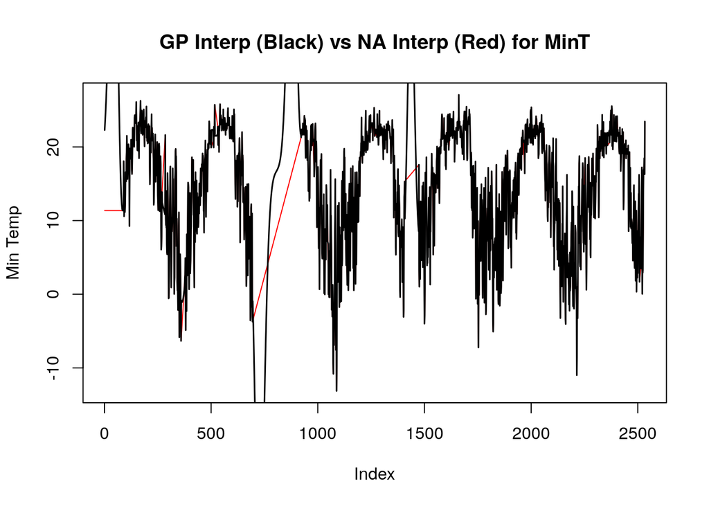

```r
plot(temp_info_TALL$MinTInterp, type = 'l', col = 'red', main = 'GP Interp (Black) vs NA Interp (Red) for MinT', ylab = 'Min Temp')
points(temp_info_TALL$MinTGP, type = 'l', lwd = 1.5)
```

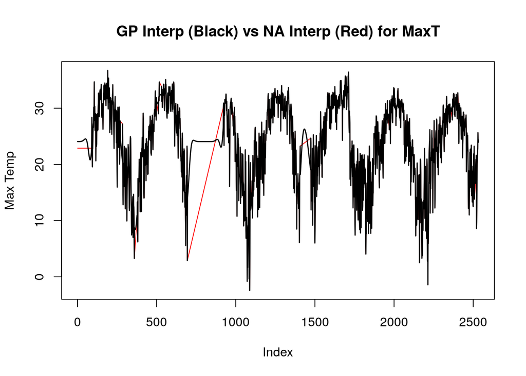

```r
plot(temp_info_TALL$MaxTInterp, type = 'l', col = 'red', main = 'GP Interp (Black) vs NA Interp (Red) for MaxT', ylab = 'Max Temp')
points(temp_info_TALL$MaxTGP, type = 'l', lwd = 1.5)
```

We see that the GP interpolations are much more wavy than the `na_interpolation` predictions. They are borrowing information across the entire dataset to estimate how the process evolves. I have saved both interpolations, and we can use whichever you prefer.

## Shortwave Radiation

Now we will pull shortwave radiation data from NEON and do some unit conversion to get their data into the format expected by DALECev.

```r
## download shortwave radiation data
neon_download(product = 'DP1.00022.001', site = 'TALL')
```

```
##   comparing hashes against local file index...
```

```
##   omitting 338 files previously downloaded
```

```r
## print unique data products and extract SRPP at
## 30 minute intervals
unique(neon_index()$table)
```

```
##  [1] "TAAT_1min-basic"                "TAAT_30min-basic"
##  [3] "EML"                            "readme"
##  [5] "sensor_positions"               "variables"
##  [7] "SRPP_1min-basic"                "SRPP_30min-basic"
##  [9] "nsae-basic"                     "categoricalCodes"
## [11] "validation"                     "ltr_chemistrySubsampling-basic"
## [13] "ltr_fielddata-basic"            "ltr_litterCarbonNitrogen-basic"
## [15] "ltr_litterLignin-basic"         "ltr_massdata-basic"
## [17] "ltr_pertrap-basic"              "bbc_chemistryPooling-basic"
## [19] "bbc_dilution-basic"             "bbc_percore-basic"
## [21] "bbc_rootChemistry-basic"        "bbc_rootmass-basic"
## [23] "vst_apparentindividual-basic"   "vst_mappingandtagging-basic"
## [25] "vst_perplotperyear-basic"       "vst_shrubgroup-basic"
```

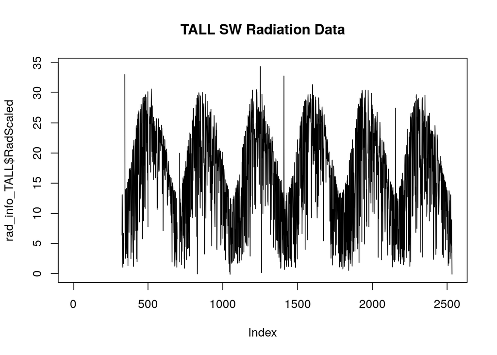

```r
rad_table <- neon_read("SRPP_30min-basic", site = 'TALL')

## format dates
rad_table$Date <- format(rad_table$endDateTime, format = '%Y-%m-%d')

## sort dates and create radiation info dataframe
sorted.Date.unique.rad <- sort(unique(rad_table$Date))
rad_info_TALL <- matrix(NA, nrow = length(sorted.Date.unique.rad), ncol = 2)
colnames(rad_info_TALL) <- c('Date', 'Rad')
rad_info_TALL <- as.data.frame(rad_info_TALL)

## extract radiation data
for (i in 1:length(sorted.Date.unique.rad)){
  rad_info_TALL$Date[i] <- sorted.Date.unique.rad[i]
  rad_info_TALL$Rad[i] <- mean(rad_table$shortRadMean[which(rad_table$Date == sorted.Date.unique.rad[i])], na.rm = TRUE)
}
## unit conversion
rad_info_TALL$RadScaled <- rad_info_TALL$Rad * .0864

## remove values that are too large
rad_info_TALL$RadScaled[which(rad_info_TALL$RadScaled > 35)] <- NA

## sanity check
plot(rad_info_TALL$RadScaled, type = 'l', main = 'TALL SW Radiation Data')
```

The plot seems to pass a sanity check at first glance.

## Latitude

This one was excruciatingly difficult, and required me to open `Google` and search for the lat/long coordinates. After several days of sifting through results, I was able to crack the Rosetta Stone and determine that TALL has a Latitude of 33.5.